# Example workflow for processing NEON eddy-covariance turbulence data with eddy4R-Docker 0.2.0

David Durden, Stefan Metzger, Natchaya Pingintha-Durden, Claire Lunch, Megan Jones

2018-10-30

## 0. Install and set up

This vignette assumes you are working with eddy4R within the Docker environment established by NEON. To get set up in that environment, follow the instructions here.

At the end of those instructions, you should have an RStudio environment running within Docker. Use that workspace for this vignette.

## 1. Install packages and set up environment

First, check for required packages and install any that aren’t already installed. Once all required packages are installed, load them into the environment.

Throughout this vignette, we use the `package::function()` syntax to explicitly refer to functions. This is done to avoid any possibility of ambiguity, in case there are functions in different packages with the same name.

```r
packReq <- c("DataCombine", "eddy4R.base", "eddy4R.qaqc",
             "ff", "ffbase", "methods", "rhdf5","splus2R")
base::lapply(packReq, function(x) {
  print(x)
  if(base::require(x, character.only = TRUE) == FALSE) {
    utils::install.packages(x)
    base::library(x, character.only = TRUE)
  }})
```

[output not shown]

```r
base::rm(packReq)
```

## 2. Set environment variables

Here we set file paths and basic input parameters as environment variables for convenience.

```r
# File path for the directory containing input L0' data
base::Sys.setenv("DIRINP" = "/home/eddy/inpExmp")

# File path for outputs
base::Sys.setenv("DIROUT" = "/home/eddy/out")

# Date(s) of the input data, specified here for the output file name
base::Sys.setenv("DATEOUT" = "2017-09-01")

# NEON domain, site, and data product ID of the input data
# for the output file name:
# Domain 10 = D10
# Central Plains Experimental Range = CPER
# Bundled eddy covariance data = 00200.001
base::Sys.setenv("FILEOUTBASE" = "NEON.D10.CPER.00200.001")

# Flag to indicate to the eddy4R.base::def.para.flow()
# function that the variables above can be found as
# environment variables, instead of provided as function
# inputs
base::Sys.setenv("METHPARAFLOW" = "EnvVar")
```

## 3. Read in metadata

Pass along the environment variables defined in section 2, then read in additional parameters from the HDF5 file.

```r
# In this section, define and/or read in a number of terms and
# parameters.

# Create an empty list for parameters.
Para <- base::list()

# Use the def.para.flow() function to specify the metadata are stored
# in environment variables, and give file paths to input and output.
# You will see a number of warning messages in response to this line,
# but if you can proceed with the next several commands, don't worry
# about the warnings here.
Para$Flow <- eddy4R.base::def.para.flow(MethParaFlow = "EnvVar")
# The args() function can be used to see the full list of function
# arguments available in def.para.flow().
# Additional metadata can be passed to the function as well, by
# assigning a variable name in the functional call.
base::args(eddy4R.base::def.para.flow)
```

```
#> function (Deve = TRUE, DirFilePara = NULL, DirInp = NA, DirMnt = NA,
#>     DirOut = NA, DirTmp = NA, DirWrk = NA, DateOut = NULL, FileOutBase = NULL,
#>     Read = "hdf5", VersDp = c("001", "004")[1], VersEddy = "latest",
#>     MethParaFlow = c("DfltInp", "EnvVar")[1], UrlInpRefe, UrlOutRefe,
#>     ...)
#> NULL
```

```r
# Get the NEON-specific 4-letter code for the site location (Loc)
# from the dp0p input file
Para$Flow$Loc <- eddy4R.base::def.para.site(FileInp = Para$Flow$DirFilePara)$Loc

# Get the level of the tower top (LvlTowr) from the dp0p input file
Para$Flow$LvlTowr <- eddy4R.base::def.para.site(FileInp = Para$Flow$DirFilePara)$LvlTowr

# Use the def.hdf5.read.para() function to extract parameters
# from the metadata in the input file and assign them to the
# parameter list.

# For each variable to be written out, set the aggregation
# parameters.
# Variables:
#   amrs: Attitude Motion Reference System
#   co2turb: Turbulent CO2 flux
#   h2oTurb: Turbulent H2O flux
#   soni: Windspeed and direction from sonic anemometer
# Parameters:
#   PrdIncrAgrDflt: Period Increment Aggregation Default
#   PrdWndwAgrDflt: Period Window Aggregation Default
for(idx in c("amrs", "co2Turb", "h2oTurb", "soni")) {

  Para$Flow$dp01[[idx]] <- eddy4R.base::def.hdf5.read.para(
    DirFileParaLoca = Para$Flow$DirFilePara,
    GrpName = paste0("/", Para$Flow$Loc, "/dp01/data/", idx),
    SetPara = c("PrdIncrAgrDflt", "PrdWndwAgrDflt")
  )

}
# AngEnuXaxs: Planar fit coefficient of the x axis
# AngEnuYaxs: Planar fit coefficient of the y axis
# Ofst: Planar fit offset
# ZoneTime: Time zone of data collection
# Note that a future release of the eddy4R package will
# include a planar fit function, which will allow you to
# set the planar fit coefficients to NA here, and then
# use the function to estimate them. This workflow will
# require a longer window of input data, on the order of
# days to weeks, be provided to determine a robust
# planar regression for the data.
Para$Sci <- eddy4R.base::def.hdf5.read.para(
  DirFileParaLoca = Para$Flow$DirFilePara,
  GrpName = Para$Flow$Loc,
  SetPara = c("Pf$AngEnuXaxs", "Pf$AngEnuYaxs", "Pf$Ofst", "ZoneTime")
)

# In the next 5 commands, get the sampling frequency (FreqSamp)
# of each instrument from the parameters in the input file:
# irgaTurb: Turbulent flux gas analyzer
# mfcSampTurb: Mass flow controller
# valvValiNemaTurb: Valve Validation Nema enclosure Turbulence
# soni, amrs: See above
Para$Sci$dp0p$irgaTurb <- def.hdf5.read.para(
      DirFileParaLoca = Para$Flow$DirFilePara,
      GrpName = paste0("/", Para$Flow$Loc, "/dp0p/data/irgaTurb"),
      SetPara = c("FreqSamp")
)

Para$Sci$dp0p$mfcSampTurb <- def.hdf5.read.para(
      DirFileParaLoca = Para$Flow$DirFilePara,
      GrpName = paste0("/", Para$Flow$Loc, "/dp0p/data/mfcSampTurb"),
      SetPara = c("FreqSamp")
)

Para$Sci$dp0p$valvValiNemaTurb <- def.hdf5.read.para(
      DirFileParaLoca = Para$Flow$DirFilePara,
      GrpName = paste0("/", Para$Flow$Loc, "/dp0p/data/valvValiNemaTurb"),
      SetPara = c("FreqSamp")
)
# For the sonic anemometer, also get the angle of the z axis
# relative to the North-East-Down coordinate system used
# for sonic anemometer installation (AngNedZaxs)
Para$Sci$dp0p$soni <- def.hdf5.read.para(
      DirFileParaLoca = Para$Flow$DirFilePara,
      GrpName = paste0("/", Para$Flow$Loc, "/dp0p/data/soni"),
      SetPara = c("AngNedZaxs","FreqSamp")
)

Para$Sci$dp0p$amrs <- def.hdf5.read.para(
      DirFileParaLoca = Para$Flow$DirFilePara,
      GrpName = paste0("/", Para$Flow$Loc, "/dp0p/data/amrs"),
      SetPara = c("FreqSamp")
)

# Lag$TimeDiff: The time lag to align gas concentration data
# with wind measurements, allowing for travel time from the inlet
# to the gas analyzer.
# The next two commands create the TimeDiff parameter for CO2
# and H2O, but leave them set to NA. Lag time is calculated by
# eddy4R.base::def.lag(). If you prefer to set it manually,
# the def.lag() function can also set it.
Para$Sci$dp01$co2Turb$RtioMoleDryCo2 <- def.hdf5.read.para(
        DirFileParaLoca = Para$Flow$DirFilePara,
        GrpName = paste0("/", Para$Flow$Loc, "/dp01/data/co2Turb/",
                         Para$Flow$LvlTowr, "_30m/rtioMoleDryCo2"),
        SetPara = c("Lag$TimeDiff")
)

Para$Sci$dp01$h2oTurb$RtioMoleDryH2o <- def.hdf5.read.para(
        DirFileParaLoca = Para$Flow$DirFilePara,
        GrpName = paste0("/", Para$Flow$Loc, "/dp01/data/h2oTurb/",
                         Para$Flow$LvlTowr, "_30m/rtioMoleDryH2o"),
        SetPara = c("Lag$TimeDiff")
)

# Create a version label for your outputs, using the
# current system time
Para$Flow$VersDp <- paste0(Para$Flow$VersDp, "_",
                           format(Sys.time(), "%Y%m%d_%H%M%S_%Z"))

# Create a list of the sampling frequencies of the essential
# instruments, extracted from the input data above.
FreqSamp <- list(
  "irgaTurb" = Para$Sci$dp0p$irgaTurb$FreqSamp,
  "mfcSampTurb" = Para$Sci$dp0p$mfcSampTurb$FreqSamp,
  "valvValiNemaTurb" = ifelse(length(as.numeric(Para$Sci$dp0p$valvValiNemaTurb$FreqSamp))==0,
                              0.2, as.numeric(Para$Sci$dp0p$valvValiNemaTurb$FreqSamp)),
  "soni" = Para$Sci$dp0p$soni$FreqSamp,
  "amrs" = Para$Sci$dp0p$amrs$FreqSamp
)
```

## 4. Variable ranges

Set plausible ranges for the input variables, to be tested on ingest. Then set paths for the working directory.

```r
# Create an empty list for range values.
Rng <- list()

# Set ranges for gas analyzer variables:
# densMoleCo2: CO2 molar density, mol m-3
# densMoleH2o: H2O molar density, mol m-3
# presAtm: Atmospheric pressure, Pa
# presDiff: Difference in pressure, Pa
# rtioMoleDryCo2: Mole ratio of CO2 in air, mol mol-1
# rtioMoleDryH2o: Mole ratio of H2O in air, mol mol-1
# tempIn: Temperature of air at inlet, K
# tempOut: Temperature of air at outlet, K
Rng$irgaTurb <- data.frame(
  "densMoleCo2" = c(0,30) * 1e-3,
  "densMoleH2o" = c(0,1500) * 1e-3,
  "presAtm" = c(50,120) * 1e3,
  "presDiff" = c(-10,1) * 1e3,
  "rtioMoleDryCo2" = c(300,450) * 1e-6,
  "rtioMoleDryH2o" = c(0,30) * 1e-3,
  "tempIn" = c(220,330),
  "tempOut" = c(220,330)
)

# Set ranges for sonic anemometer variables:
# veloXaxs: Velocity on the x axis, m s-1
# veloYaxs: Velocity on the y axis, m s-1
# veloZaxs: Velocity on the z axis, m s-1
# veloSoni: Speed of sound, m s-1
Rng$soni <- data.frame(
  "veloXaxs"=c(-50,50),
  "veloYaxs"=c(-50,50),
  "veloZaxs"=c(-10,10),
  "veloSoni"=c(300,400)
)

# Set ranges for attitude and motion reference variables:
# angXaxs: Deviation from the x axis, degree
# angYaxs: Deviation from the y axis, degree
# angZaxs: Deviation from the z axis, degree
Rng$amrs <- data.frame(
  "angXaxs"=c(-360,360),
  "angYaxs"=c(-360,360),
  "angZaxs"=c(-360,360)
)

# Set directories and file paths
# As written, this vignette uses the default paths. To use custom
# paths, assign the file paths you want to use to the parameters
# Para$Flow$DirWrk, Para$Flow$DirInp, and Para$Flow$DirOut before
# proceeding to the code below.

# Working directory
# Default: use a temporary working directory on Docker filesystem
if(is.na(Para$Flow$DirWrk)) {
  Para$Flow$DirWrk <- tempdir()

  # Optional: create a user-specified working directory, e.g. on host filesystem
  } else {
    dir.create(Para$Flow$DirWrk, recursive = TRUE, showWarnings = FALSE)
  }

# Directory for input data
# Default: use temporary working directory on Docker filesystem
if(is.na(Para$Flow$DirInp)) {
  Para$Flow$DirInp <- paste0(Para$Flow$DirWrk, "/inpRefe")

  # Optional: create user-specified input directory
  } else {
    dir.create(Para$Flow$DirInp, recursive = TRUE, showWarnings = FALSE)
  }

# Directory for output data
# Default: use temporary working directory on Docker filesystem
if(is.na(Para$Flow$DirOut)) {
  Para$Flow$DirOut <- paste0(Para$Flow$DirWrk, "/out")

  # Optional: create user-specified input directory
  } else {
    dir.create(Para$Flow$DirOut, recursive = TRUE, showWarnings = FALSE)
  }
```

## 5. Read in data!

We have found in testing that this section may run into trouble if Docker is not assigned sufficient memory in your system. If you find that this section hangs or errors out, try opening Docker -> Preferences -> Advanced and increasing the memory allotment.

```r
# Create empty lists for data and quality flags
data <- list()
qfqmFlag <- list()

# Index for the number of days iterated over, and empty list for outputs
numDate <- 0
out <- list()

# Loop over days in input data (in the example data here, there is
# only one day)
for(date in Para$Flow$DateOut) {
  numDate <- numDate + 1

  # Begin: read raw data from HDF5 file
  if(Para$Flow$Read == "hdf5") {

    # Create directory structure
    dir.create(paste(Para$Flow$DirOut, "/", Para$Flow$Loc, "/",
                     Para$Flow$VersDp, sep=""),
               recursive = TRUE, showWarnings = FALSE)

    # Create empty list for inputs
    inp <- list()

    # Loop over instruments
    for(Var in c("irgaTurb", "mfcSampTurb", "valvValiNemaTurb", "soni", "amrs")){

      # Use data read function, assigning results to a temporary variable
      tmp <- eddy4R.base::wrap.hdf5.read(
        DirInpLoca = Para$Flow$DirInp,
        SiteLoca = Para$Flow$Loc,
        DateLoca = date,
        VarLoca = Var,
        FreqLoca = FreqSamp[[Var]],
        LvlTowr = Para$Flow$LvlTowr,
        RngLoca = Rng,

        # Assign de-spiking parameters:
        #   widt: WndwDspkBr86 de-spiking median filter window width [s]
        #   nbin: NumDspkBr86Bin de-spiking histogram bins initial number/step size
        #   rest: ThshDspkBr86Reso de-spiking resolution threshold
        DespLoca = list(widt = 9,
                        nbin = 2,
                        rest = 10
                        )
        )

      # Read in quality flags from HDF5 file
      if(!Var %in% "valvValiNemaTurb"){

        tmpQfqm <- eddy4R.base::def.hdf5.read.qfqm(
          DirInpLoca = Para$Flow$DirInp,
          SiteLoca = Para$Flow$Loc,
          DateLoca = date,
          VarLoca = Var,
          FreqLoca = FreqSamp[[Var]],
          LvlTowr = Para$Flow$LvlTowr
        )

      # Remove timestamp from flags, since timestamps will be
      # saved elsewhere
      tmpQfqm <- tmpQfqm[,grep("time",names(tmpQfqm),invert = T)]
      }

      # Copy results from temporary variables to inp

      # Time domain, including unit assignment
      if(Var == "irgaTurb") {
        inp$time <- ff::as.ffdf.data.frame(data.frame(UTC = tmp$time))
        base::attr(x = inp$time$UTC, which = "unit") <- "YYYY-MM-DD hh:mm:ss.sss"
        }

      # Sensor data, including unit assignment
      inp$data[[Var]] <- ff::as.ffdf.data.frame(tmp$data)
      for(idx in base::names(tmp$data))
        base::attr(x = inp$data[[Var]][[idx]], which = "unit") <-
        base::attr(x = tmp$data, which = "unit")[[idx]]

      if(exists("tmpQfqm")) inp$qfqm[[Var]] <- ff::as.ffdf.data.frame(tmpQfqm)

      # Remove temporary variables
      rm(tmp)
      if(exists("tmpQfqm"))
        rm(tmpQfqm)
      invisible(gc())

      # End loop over instruments
      }; rm(Var)

    # Calculate derived quantities: daily extent, native resolution
    inp <- eddy4R.base::wrap.derv.prd.day(
      inpList = inp,
      ZoneTime = Para$Sci$ZoneTime,
      AngZaxsSoniInst = Para$Sci$dp0p$soni$AngNedZaxs
      )

    # Print status message
    print(paste0(format(Sys.time(), "%F %T"), ": dataset ", date,
                 ": derived quantities calculated (daily extent, native resolution)"))

  # End of raw data read
  }

  # Assign daily data and attributes to file-backed objects
  #   to keep RAM footprint small
  # If loop is on the first day, create the attributes:
  if(numDate == 1) {

    # IRGA
    data$irgaTurb <- inp$data$irgaTurb
    qfqmFlag$irgaTurb <- inp$qfqm$irgaTurb

    # MFC
    data$mfcSampTurb <- inp$data$mfcSampTurb
    qfqmFlag$mfcSampTurb <- inp$qfqm$mfcSampTurb

    # Sonic anemometer
    data$soni <- inp$data$soni
    qfqmFlag$soni <- inp$qfqm$soni

    # AMRS
    data$amrs <- inp$data$amrs
    qfqmFlag$amrs <- inp$qfqm$amrs

    # Time objects
    data$time <- inp$time
    qfqmFlag$time <- inp$time

    # If loop is on any day after the first, append the attributes:
    } else {

      # IRGA
      data$irgaTurb <- ffbase::ffdfappend(x = data$irgaTurb,
                                          dat = inp$data$irgaTurb)
      qfqmFlag$irgaTurb <-  ffbase::ffdfappend(x =qfqmFlag$irgaTurb,
                                               dat = inp$qfqm$irgaTurb)

      # MFC
      data$mfcSampTurb <- ffbase::ffdfappend(x = data$mfcSampTurb,
                                             dat = inp$data$mfcSampTurb)
      qfqmFlag$mfcSampTurb <-  ffbase::ffdfappend(x = qfqmFlag$mfcSampTurb,
                                                  dat = inp$qfqm$mfcSampTurb)

      # valvValiNemaTurb
      data$valvValiNemaTurb <- ffbase::ffdfappend(x = data$valvValiNemaTurb,
                                                  dat = inp$data$valvValiNemaTurb)
      qfqmFlag$valvValiNemaTurb <- ffbase::ffdfappend(x = qfqmFlag$valvValiNemaTurb,
                                                      dat = inp$qfqm$valvValiNemaTurb)

      # Sonic anemometer
      data$soni <- ffbase::ffdfappend(x = data$soni, dat = inp$data$soni)
      qfqmFlag$soni <-  ffbase::ffdfappend(x =qfqmFlag$soni, dat = inp$qfqm$soni)

      # AMRS
      data$amrs <- ffbase::ffdfappend(x = data$amrs, dat = inp$data$amrs)
      qfqmFlag$amrs <-  ffbase::ffdfappend(x =qfqmFlag$amrs, dat = inp$qfqm$amrs)

      # Time objects
      data$time <- ffbase::ffdfappend(x = data$time, dat = inp$time)
      qfqmFlag$time <-  ffbase::ffdfappend(x =qfqmFlag$time, dat = inp$time)

    # End attributes assignment
    }

  # Remove temporary list of input variables
  inp <- NULL
  inpQfqm <- NULL
  invisible(gc())

# End loop
}
```

```
#> [1] "2018-10-30 12:56:13: dataset 2017-09-01: irgaTurb hdf5 read-in complete"
#> [1] "2018-10-30 12:56:15: dataset 2017-09-01: irgaTurb hdf5 attributes complete"
#> [1] "2018-10-30 12:56:16: dataset 2017-09-01: irgaTurb unit conversion complete"
#> [1] "2018-10-30 12:56:16: dataset 2017-09-01: irgaTurb regularization not selected"
#> [1] "2018-10-30 12:56:16: dataset 2017-09-01: irgaTurb sensor diagnostics not selected"
#> [1] "2018-10-30 12:56:16: dataset 2017-09-01: irgaTurb range test not selected"
#> 161 out of 1728000 time series values in y are missing.
#> 432161 out of 1728000 time series values in y are missing.
#> 162 out of 1728000 time series values in y are missing.
#> 162 out of 1728000 time series values in y are missing.
#> 162 out of 1728000 time series values in y are missing.
#> 162 out of 1728000 time series values in y are missing.
#> 162 out of 1728000 time series values in y are missing.
#> 162 out of 1728000 time series values in y are missing.
#> [1] "2018-10-30 12:56:34: dataset 2017-09-01: irgaTurb de-spiking complete"
```

[output cut: 212 more lines]

## 6. Begin data analysis.

The first step is to get the half-hourly indices used to extract data from the file-backed objects into internal memory as a list of data.frames. Then, the lag time correction is applied to the gas analyzer (IRGA) data, based on the sonic anemometer vertical velocity, using the eddy4R.base::def.lag() function. After the lag correction has been applied, the half-hourly derived data sub-products for relative humidity and dewpoint temperature are calculated.

Then, the input data that are provided as NEON Level 0 prime data products (high frequency raw data that has been time regularized and units converted) are subsetted, and naming syntax is changed to match NEON Level 1 data product output conventions. eddy4R.base::wrap.dp01.agr.prd() is used to calculate the 1-minute averaged data and quality metrics. Finally, we calculate 30-minute data using eddy4R.base::wrap.dp01() and determine the quality metrics and final quality flag using eddy4R.base::wrap.dp01.qfqm.ecte().

```r
# Kick off with a time stamp when processing starts
print(paste0(format(Sys.time(), "%F %T"), ": dataset ", date,
             " derived quantities (vignette) begin"))
```

```
#> [1] "2018-10-30 12:58:40: dataset 2017-09-01 derived quantities (vignette) begin"
```

```r
# Create empty list for working parameters and variables
wrk <- list()

# Create empty list for quality flag/quality metric data
qfqm <- list()

# Set begin and end time for each 30-minute averaging interval,
# for each instrument system
invisible(lapply(names(data), function(x) {
  if(x == "amrs") {
    wrk$idx[[x]] <<- eddy4R.base::def.idx.agr(time = data$amrs$time,
                                              PrdAgr = 1800,
                                              FreqLoca = 40)
  }  else {
    wrk$idx[[x]] <<- eddy4R.base::def.idx.agr(time = data$time$UTC,
                                              PrdAgr = 1800,
                                              FreqLoca = 20)
  }}))

# If Deve flag, meaning Development, is set to TRUE, only run a
# small number of iterations for testing purposes. Otherwise
# iterate over all variables and time periods. This vignette
# sets Deve=TRUE.
if (Para$Flow$Deve == TRUE) {
  iter <- 10
  } else {
    iter <- max(sapply(names(wrk$idx),
                       function(x) length(wrk$idx[[x]]$idxBgn)))
  }

# Another time stamp: Loop start
print(paste0(format(Sys.time(), "%F %T"), ": dataset ",
             date, " DP01 calculation begin"))
```

```
#> [1] "2018-10-30 12:58:40: dataset 2017-09-01 DP01 calculation begin"
```

```r
numAgr <- 0

for(idxAgr in 1:iter) {

  numAgr <- numAgr + 1

  # Create an identifier for the loop iterations
  lvlAgr <- paste0("numAgr", ifelse(numAgr < 10,
                                    paste0("0", numAgr),
                                    numAgr))

  # Create empty list for data
  wrk$data <- list()

  # Loop over sensor systems to grab the data indices for the current aggregation period (i.e. 30 minute period of data).
  for(idxSens in names(data)) {
    wrk$data[[idxSens]] <- data[[idxSens]][wrk$idx[[idxSens]]$idxBgn[idxAgr]:
                                             wrk$idx[[idxSens]]$idxEnd[idxAgr],]
    wrk$qfqm[[idxSens]] <- qfqmFlag[[idxSens]][wrk$idx[[idxSens]]$idxBgn[idxAgr]:
                                                 wrk$idx[[idxSens]]$idxEnd[idxAgr],]

    # Assign units for each variable, from metadata
    for(idxVar in base::names(wrk$data[[idxSens]])) {

      base::attr(x = wrk$data[[idxSens]][[idxVar]], which = "unit") <-
        base::attr(x = data[[idxSens]][[idxVar]], which = "unit")

      }; rm(idxVar)

    }; rm(idxSens)

  # Lag time correction
  # Select variables to be lagged
  var <- c("rtioMoleDryCo2", "rtioMoleDryH2o", "rtioMassH2o", "presH2o")

  # Loop over lag correction variables
  tmpRun <- 0
  for(idxVar in var) {

    tmpRun <- tmpRun + 1

    # Is lag pre-determined or calculated?
    # If lag is calculated:
    if((base::length(base::grep(pattern = "CO2",
                                x = idxVar,
                                ignore.case = TRUE)) > 0 &&
        is.na(Para$Sci$dp01$co2Turb$RtioMoleDryCo2$`Lag$TimeDiff`)) |
       (base::length(base::grep(pattern = "H2O",
                                x = idxVar, ignore.case = TRUE)) > 0 &&
        is.na(Para$Sci$dp01$h2oTurb$RtioMoleDryH2o$`Lag$TimeDiff`))) {

      # Calculate lag
      lag <- def.lag(refe = wrk$data$soni$veloZaxs,
                     meas = wrk$data$irgaTurb[[idxVar]],
                     lagMax = 2 * FreqSamp$irgaTurb,
                     lagCnst = TRUE,
                     # Only negative lags permitted
                     lagNgtvPstv = c("n", "p", "np")[1],
                     lagAll = TRUE,
                     freq = FreqSamp$irgaTurb,
                     hpf = TRUE)

      } else {

        # If lag is pre-determined:
        lag <- list()
        lag$lag <- ifelse(base::length(base::grep(pattern = "CO2",
                                                  x = idxVar,
                                                  ignore.case = TRUE)) > 0,
                          Para$Sci$dp01$co2Turb$RtioMoleDryCo2$`Lag$TimeDiff`,
                          Para$Sci$dp01$h2oTurb$RtioMoleDryH2o$`Lag$TimeDiff`)
        lag$corrCros <- NaN

      }

    # Shift data according to lag time
    tmpAttr <- attributes(wrk$data$irgaTurb[[idxVar]])$unit
    if(!is.na(lag$lag)) {
      wrk$data$irgaTurb[[idxVar]] <-
        DataCombine:::shift(VarVect = wrk$data$irgaTurb[[idxVar]],
                            shiftBy = - lag$lag, reminder = FALSE)
    }
    attributes(wrk$data$irgaTurb[[idxVar]])$unit <- tmpAttr; rm(tmpAttr)

    # Store lag times
    if(tmpRun == 1) {
      tmpLag <- lag$lag / FreqSamp$irgaTurb
      tmpCorrCros <- lag$corrCros
      } else {
        tmpLag <- c(tmpLag, lag$lag / FreqSamp$irgaTurb)
        tmpCorrCros <- c(tmpCorrCros, lag$corrCros)
      }

    # End of lag correction loop
    }

  # Remove temporary variables
  names(tmpLag) <- var
  tmpLag <- data.frame(t(tmpLag))
  names(tmpCorrCros) <- var
  tmpCorrCros <- data.frame(t(tmpCorrCros))
  rm(tmpRun, lag, idxVar, var)

  # Derived variables
  # Fast air temperature
  wrk$data$soni$T_air_SONIC <- unlist(wrk$data$soni$tempSoni /
                                        (1 + 0.51 * wrk$data$irgaTurb$rtioMassH2o))
  base::attr(x = wrk$data$soni$T_air_SONIC, which = "unit") <- "K"

  # Ambient water vapor saturation pressure
  if(!is.na(mean(wrk$data$soni$T_air_SONIC, na.rm=TRUE))) {
    wrk$data$irgaTurb$presH2oSatAtm <-
      unlist(def.pres.h2o.sat.temp.mag(temp=wrk$data$soni$T_air_SONIC))
    } else {
      wrk$data$irgaTurb$presH2oSatAtm <-
        rep(NaN, length(wrk$data$soni$T_air_SONIC))
    }
  base::attr(x = wrk$data$irgaTurb$presH2oSatAtm, which = "unit") <- "Pa"

  # Ambient relative humidity, including adjustment of partial
  # pressure from cell to ambient via Dalton's law
  wrk$data$irgaTurb$rhAtm <-
    def.rh.pres.h2o.pres.sat.h2o(presH2o = wrk$data$irgaTurb$presH2o,
                                 presH2oSat = wrk$data$irgaTurb$presH2oSatAtm) *
    mean(wrk$data$irgaTurb$presAtm, na.rm=TRUE) /
    mean(wrk$data$irgaTurb$presSum, na.rm=TRUE)

  # Ambient dew point
  wrk$data$irgaTurb$tempDew <-
    def.temp.dew.pres.h2o.temp.mag(presH2o = wrk$data$irgaTurb$presH2o,
                                   temp = wrk$data$soni$T_air_SONIC)

  # Assemble data for Level 1 data product generation

  # Create empty temporary lists
  # For data
  wrk$tmp$data <- list()

  # For quality flags and quality metrics
  wrk$tmp$qfqm <- list()

  # Assemble data
  # For sonic anemometer
  wrk$tmp$data$soni <- data.frame(stringsAsFactors = FALSE,
                                  "veloXaxsErth" = wrk$data$soni$veloXaxs,
                                  "veloYaxsErth" = wrk$data$soni$veloYaxs,
                                  "veloZaxsErth" = wrk$data$soni$veloZaxs,
                                  "veloXaxsYaxsErth" = wrk$data$soni$veloXaxsYaxsErth,
                                  "angZaxsErth" = wrk$data$soni$angZaxsErth,
                                  "tempSoni" = wrk$data$soni$tempSoni,
                                  "tempAir" = wrk$data$soni$T_air_SONIC)

  # For AMRS
  wrk$tmp$data$amrs <- data.frame(stringsAsFactors = FALSE,
                                  "angNedXaxs" = wrk$data$amrs$angXaxs,
                                  "angNedYaxs" = wrk$data$amrs$angYaxs,
                                  "angNedZaxs" = wrk$data$amrs$angZaxs)

  # For CO2
  wrk$tmp$data$co2Turb <- data.frame(stringsAsFactors = FALSE,
                                     "rtioMoleDryCo2" = wrk$data$irgaTurb$rtioMoleDryCo2,
                                     "densMoleCo2" = wrk$data$irgaTurb$densMoleCo2,
                                     "presAtm" = wrk$data$irgaTurb$presAtm,
                                     "presSum" = wrk$data$irgaTurb$presSum,
                                     "frt00Samp" = wrk$data$mfcSampTurb$frt00,
                                     "tempAve" = wrk$data$irgaTurb$tempMean)

  # for H2O
  wrk$tmp$data$h2oTurb <- data.frame(stringsAsFactors = FALSE,
                                     "rtioMoleDryH2o" = wrk$data$irgaTurb$rtioMoleDryH2o,
                                     "densMoleH2o" = wrk$data$irgaTurb$densMoleH2o,
                                     "tempDew" = wrk$data$irgaTurb$tempDew,
                                     "presAtm" = wrk$data$irgaTurb$presAtm,
                                     "presSum" = wrk$data$irgaTurb$presSum,
                                     "frt00Samp" = wrk$data$mfcSampTurb$frt00,
                                     "tempAve" = wrk$data$irgaTurb$tempMean)

  # Calculate data products
  # Calculate 1 and 2 minute data products
  wrk$dp01AgrSub[[lvlAgr]] <- eddy4R.base::wrap.dp01.agr.prd(inpList = wrk)

  # 30-minute data products
  wrk$dp01[[lvlAgr]] <- eddy4R.base::wrap.dp01(
    data = wrk$tmp$data,
    idx = c("soni", "amrs", "co2Turb", "h2oTurb")
    )

          # Standard error removed from 1- and 30- minute, it is now part of the ucrt calculation function
          lapply(names(wrk$dp01AgrSub[[lvlAgr]]$data), function(idxData){
          wrk$dp01AgrSub[[lvlAgr]]$data[[idxData]]$se <<- NULL
          wrk$dp01[[lvlAgr]][[idxData]]$se <<- NULL
          })


  # Another time stamp: Starting quality processing
  print(paste0(format(Sys.time(), "%F %T"),
               ": Beginning the qfqm data processing for data in loop...",
               idxAgr))

  # Calculate the quality metrics and determine the final quality flag
  wrk$qfqmOut[[lvlAgr]] <- eddy4R.base::wrap.dp01.qfqm.ecte(
    qfqm = wrk$qfqm,
    idx = c("soni", "amrs", "co2Turb", "h2oTurb"),
    MethMeas = "ecte",
    RptExpd = TRUE )

  # Remove temporary files
  wrk$data <- NULL
  wrk$tmp <- NULL
  invisible(gc())

# End loop
}
```

```
#> [1] "2018-10-30 12:59:00: Beginning the qfqm data processing for data in loop...1"
#> [1] "2018-10-30 12:59:31: Beginning the qfqm data processing for data in loop...2"
#> [1] "2018-10-30 13:00:01: Beginning the qfqm data processing for data in loop...3"
#> [1] "2018-10-30 13:00:32: Beginning the qfqm data processing for data in loop...4"
#> [1] "2018-10-30 13:01:03: Beginning the qfqm data processing for data in loop...5"
#> [1] "2018-10-30 13:01:34: Beginning the qfqm data processing for data in loop...6"
#> [1] "2018-10-30 13:02:05: Beginning the qfqm data processing for data in loop...7"
#> [1] "2018-10-30 13:02:36: Beginning the qfqm data processing for data in loop...8"
#> [1] "2018-10-30 13:03:08: Beginning the qfqm data processing for data in loop...9"
#> [1] "2018-10-30 13:03:39: Beginning the qfqm data processing for data in loop...10"
```

```r
print(paste0(format(Sys.time(), "%F %T"),
             ": dataset ", date,
             " DP01 calculation complete"))
```

```
#> [1] "2018-10-30 13:03:50: dataset 2017-09-01 DP01 calculation complete"
```

## 7. Aggregate data and quality metrics

Now, we aggregate the results from section 6. The first step is to aggregate the half-hourly sets of data and qfqm. Then, we plot the final quality flag and its relationship to the alpha and beta quality metrics. (alpha = fraction of data flagged by sensor and statistical plausibility tests; beta = fraction of quality flags not available due to missing data)

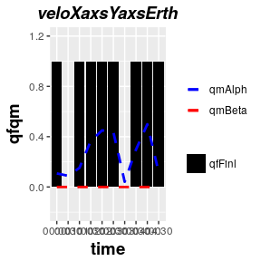

```r
# Concatenate results using def.dp01.agr.ecte()
out <- eddy4R.base::def.dp01.agr.ecte(inpList = wrk,
                                      MethSubAgr = TRUE,
                                      MethUcrt = FALSE)

# Generate qfqm table to be plotted
inpPlot <- data.frame(time =
                        format(as.POSIXct(out$time$co2Turb$timeBgn,
                                          format="%Y-%m-%d %H:%M:%S"),
                               format="%H:%M"),
                      qfFinl = out$qfqm$soni$qfFinl$veloXaxsYaxsErth,
                      qmAlph = out$qfqm$soni$qmAlph$veloXaxsYaxsErth,
                      qmBeta = out$qfqm$soni$qmBeta$veloXaxsYaxsErth)

# Plot final quality flag, alpha metric, and beta metric
library(ggplot2)

plot = ggplot(inpPlot, aes(time)) +
  geom_bar(aes(y = qfFinl, fill= "qfFinl"), stat="identity") +
  geom_line(aes(y = qmAlph, group = 1, color = "qmAlph"),
            size = 1, linetype = "dashed") +
  geom_line(aes(y = qmBeta, group = 2, color = "qmBeta"),
            size = 1, linetype = "dashed") +
  ggtitle("veloXaxsYaxsErth") +
  scale_colour_manual(" ",
                      values=c("qfFinl" = "black",
                               "qmAlph" = "blue",
                               "qmBeta" = "red")) +
  scale_fill_manual("",values="black") +
  theme(legend.key = element_blank(),
        legend.title = element_blank(),
        legend.box = "vertical",
        plot.title = element_text(size=14,
                                  face="bold.italic",
                                  hjust = 0.5),
        axis.title.x = element_text(size=14, face="bold"),
        axis.title.y = element_text(size=14, face="bold")) +
  ylim(-0.2,1.2) +
  labs(y = "qfqm")

print(plot)
```

```r
# Remove temporary files
wrk$dp01 <- NULL
wrk$dp01AgrSub <- NULL
wrk$qfqmOut <- NULL
```

## 8. Format for output

Lastly, we prepare the data for output and write it to the dp01 output HDF5 file. We first create the skeleton structure of the NEON HDF5 file using eddy4R.base::def.hdf5.crte(). We then perform some packaging of the results to match the NEON HDF5 structure and write the output to the NEON dp01 HDF5 file.

```r
# Drop the quality column (qfqm) after the example;
# these data will be added to the HDF5 structure in
# a future release
lapply(names(out$qfqm), function(x){
  out$qfqm[[x]]$qm <<- NULL
})
```

```r
# Use the def.hdf5.crte() function to generate the
# H5 file in NEON EC format
eddy4R.base::def.hdf5.crte(Date = date,
                           Site = Para$Flow$Loc,
                           LvlTowr = Para$Flow$LvlTowr,
                           DirOut = base::paste0(Para$Flow$DirOut,
                                                 "/", Para$Flow$Loc,
                                                 "/", Para$Flow$VersDp),
                           FileOutBase = Para$Flow$FileOutBase,
                           MethExpd = TRUE,
                           FileNameReadMe = "/home/eddy/inpExmp/ECTE_HDF5_readme.txt",
                           FileNameObjDesc =
                             "/home/eddy/inpExmp/ECTE_HDF5_object_description.csv")

# Determine the output filename of the file we just created
FileOut <- base::list.files(path = base::paste0(Para$Flow$DirOut,
                                                "/", Para$Flow$Loc,
                                                "/", Para$Flow$VersDp),
                            pattern = ".h5", full.names = TRUE)

# Call the wrapper function wrap.hdf5.wrte.dp01() to package
# and write data to output HDF5 files, both basic and expanded
eddy4R.base::wrap.hdf5.wrte.dp01(inpList = out,
                                 FileIn = base::paste0(Para$Flow$DirInp,
                                                       "/","ECTE_dp0p_",
                                                       Para$Flow$Loc, "_",
                                                       date, ".h5"),
                                 FileOut = FileOut,
                                 SiteLoca = Para$Flow$Loc,
                                 LvlTowr = Para$Flow$LvlTowr,
                                 MethUcrt = FALSE,
                                 MethSubAgr = TRUE)
```